# Dates and Times with `lubridate`

### Common Calculations

The `lubridate` package also contains a handful of functions to help perform common calculations:

| Function | Output |
| --- | --- |
| `yday()` | day of the year (number from 1-365) |
| `wday()` | day of week (number from 1-7 or factor label when `label=TRUE` is used) |
| `floor_date()` | rounds the date downward |
| `ceiling_date()` | rounds the date upward |
| `round_date()` | rounds the date upward/downward (whichever is closer) |

A few examples demonstrating these functions are given below:

```r
today <- Sys.Date()

## Day of year
yday(today)
```

```
## [1] 279
```

```r
## Day of week
wday(today)
```

```
## [1] 6
```

```r
# label = TRUE creates an ordered factor
wday(today, label = TRUE)
```

```
## [1] Fri
## Levels: Sun < Mon < Tue < Wed < Thu < Fri < Sat
```

```r
## Rounding
floor_date(today, unit = "month") # down to nearest month
```

```
## [1] "2023-10-01"
```

```r
ceiling_date(today, unit = "month") # up to nearest month
```

```
## [1] "2023-11-01"
```

```r
round_date(today, unit = "month") # to whichever is closest
```

```
## [1] "2023-10-01"
```

**Question 2**: Create a date/time object for 9:15pm in Los Angeles on February 14, 2020. Then, round this date to the nearest day, then determine which day of the week that day was.

### Times without dates

Sometimes you’ll encounter data consisting of times without an attached date. These might be times within a day such as “01:30:00” or 1:30 AM, or duration of time such as 1 hour, 30 minutes, and 0 seconds.

The `lubridate` package provides a simple storage class for times without dates that can be applied using the `hms()` function.

```r
## Example
(time <- hms("01:10:00"))
```

```
## [1] "1H 10M 0S"
```

```r
#
60*hour(time) + minute(time)
```

```
## [1] 70
```

Because these objects are stored at `00:00:00` we can perform arithmetic on them directly:

```r
hms("01:10:00") - hms("01:05:00")
```

```
## [1] "5M 0S"
```

We can also exploit this fact to easily convert results to seconds using pipelines:

```r
(hms("01:10:00") - hms("01:05:00")) %>% seconds()
```

```
## [1] "300S"
```

$~$

### Practice (required)

**Question 3**: The [2015 Boston Marathon](https://en.wikipedia.org/wiki/2015_Boston_Marathon) took place on April 20th, 2015. It was the 119th running of one of the world’s most well-known races. The data below contain information, results, and splits for each finisher of the marathon:

```r
marathon <- read.csv("https://remiller1450.github.io/data/BostonMarathon2015.csv")
```

**Part A**: A marathon is approximately 26.2 miles, making the first half 13.1 miles. Calculate the per mile pace (in seconds) for each participant in the first half of the race. Be sure to store your results.

**Part B**: Now calculate the pace per mile in the second half of the race. Be sure to store your results.

**Part C**: Now create a scatterplot displaying the relationship between pace per mile in the first half of the race vs. pace per mile in the second half of the race by age and sex. To do this, you should assemble your results from Parts A and B into a data frame, and you should also include the “Age” and “M.F” columns from the original data when you create this data frame. A target graphic is given below. *Note*: `hms::scale_x_time()` and `hms::scale_y_time()` can be used to display your first half and second half paces on a time scale. The graph shown below uses the argument `alpha = 0.2` to reduce the impact of over-plotting, and a 45-degree line is added using `geom_abline()`.

Note: If you get an error that `hms` is not available, you need to install it with `install.packages("hms")`. However, do not load the entire package with `library(hms)`, as this will cause problems with the `lubridate` package. Instead, to use a function from a package without loading the entire package, we use the double colon `::` with the form `packagename::function`. In this case, we are wanting to use the function `scale_x_time()` from the package `hms`, hence `hms::scale_x_time()`.

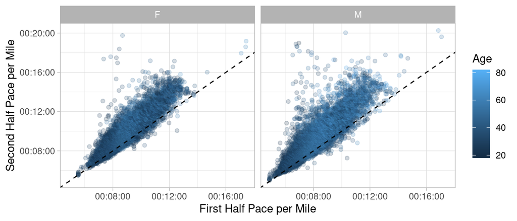

$~$